# Guia CSS

Javier Ribal del Río

23/5/2021

# 1 INTRODUCCIÓN

 Antes de explicar el funcionamiento de Css es necesario conocer algunas de las cosas básicas de la informática:

## 1.1 Texto plano

 La gran inmensa mayoría de programación se desarrolla o es editada en un archivo de texto plano. Y, ¿Qué es esto de un archivo de texto plano? Un archivo de texto plano (del inglés :uk: : *plain text*) es un archivo que contiene exclusivamente caracteres, sin ningún formato; es decir sin negritas, itálicas subrayados, colores, tamaño de letra, fuente …

 Técnicamente cualquier archivo puede abrirse desde un editor de texto plano. Pero, por ejemplo si abriéramos un archivo .MP3 no entenderíamos su contenido.

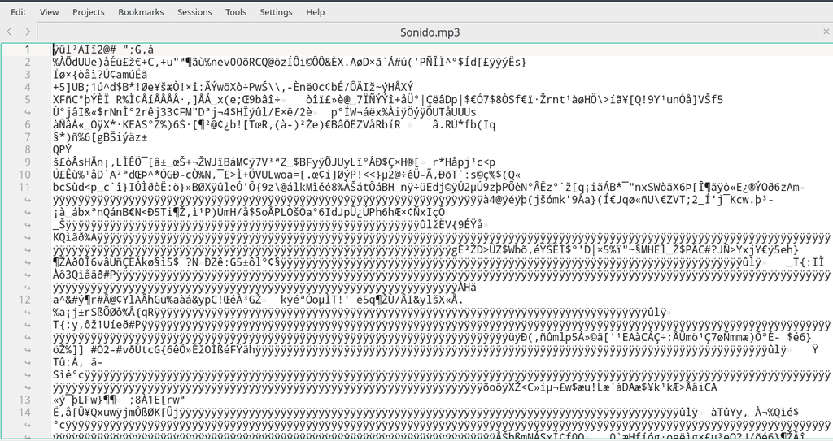

Foto de una archivo mp3 abierto con un editor de textos planos (Kate)

*Foto de una archivo mp3 abierto con un editor de textos planos (Kate)*

 Los tres grandes sistemas operativos tiene incluido un editor de textos plano como predeteriminado: MacOs tiene Text Edit, Windows tiene el mítico Bloc de Notas y en el caso de Linux/Unix tienen a nano o vim.

## 1.2 Lenguajes de Programación

 Un lenguaje de programación es un lenguaje formal (o artificial, es decir, un lenguaje con reglas gramaticales bien definidas sintaxis, punto 1.3) que le proporciona a una persona, en este caso el programador, la capacidad de escribir (o programar) una serie de instrucciones o secuencias de órdenes en forma de algoritmos con el fin de controlar el comportamiento físico o lógico de un sistema informático, de manera que se puedan obtener diversas clases de datos o ejecutar determinadas tareas. A todo este conjunto de órdenes escritas mediante un lenguaje de programación se le denomina programa informático.

## 1.3 Sintaxis

 En programación, se llama sintaxis a la forma de escribir el código. Este ejemplo es muy claro.

```cpp
//C++

cout << "Hola mundo" << endl;
```

```
//C#

console.log("Hola mundo\n");
```

## 1.4 Sintaxis de CSS y Funcionamineto

 En este apartado se explicara el funcionamiento de Css y su sintaxis, pero, primero de todo hay que solucionar varios aspectos que pueden generar controversia. **Css se utiliza para dar formato a una web**, esto puede generar controversia, ya que los archivos Css son de texto plano, y como ya se ha explicado antes los archivos planos no pueden tener formato. No esta del todo claro que Css sea un lenguaje de programación, hay expertos que lo consideran como un lenguaje de progrmación por que tiene las caracteristicas de un lenguaje de programación; pero hay gente que dice que no es un lenguaje de programación porque se dice que le faltan las estructuras básicas de programación, como pueden ser las condicionales o los bucles. Dicho esto vamos a explicar el funcionamiento de css.

```css
.texto_azul_con_margen{

    /*Esto es un comentario*/
    background-color: blue;

    margin:5px;
}
```

### 1.4.1 Partes del Código

- “.texto_azul_con_margen” indica a que se le va aplicar el formato
- “{” Indica que se va a comenzar a definir el formato del elemento anterior
- “Esto es un comentario” es un ejemplo de comentario, los comentarios son anotaciones que puedes hacer en propio código sin que se altere el funcionamiento del mismo
- “background-color” y “margin” indican la característica del formato que se va a definir
- “:” los dos-puntos indican que se va definir el valor de la característica del formato
- El “blue” y el “5px” es el valor del formato definido, 5 px de margin y blue de backgorund color
- “;” Los punto-coma indican que se cambia de caracteristica de formato
- “}” Indica que se acaba el formato